# Markdown

Week 2 – Lecture D

Author

Affiliations

Jelmer Poelstra

[CFAES Bioinformatics Core, Ohio State University](https://go.osu.edu/bioinformatics-core)

[Dept. of Plant Pathology, Ohio State University](https://plantpath.osu.edu)

Presented on

September 2, 2026

Last modified

August 13, 2026

## 1 Introduction

### 1.1 Overview

The previous lecture emphasized the importance of research documentation, and recommended using plain-text files to do so. Now, you will learn to use **Markdown**, a simple plain-text markup language that is a great option for writing your documentation.

## 2 Markdown

Markdown is a lightweight text “markup language” that provides formatting options for plain-text files. Think of it as a much simpler version of HTML, which also comes in plain-text source code/format and a rendered counterpart. A *source* Markdown file can be “**rendered**” to produce an output file in a variety of formats like PDF and (rendered) HTML.

As a first example of the kind of markup you can do: surrounding one or more characters by single or double asterisks (**`*`**) will apply italic and bold formatting, respectively:

- When you write `*italic example*` this will be rendered as: *italic example*.
- When you write `**bold example**`this will be rendered as: **bold example**.

### 2.1 Markdown in VS Code

When you save a file in VS Code with the extension `.md` (short for Markdown) extension, as you have done:

Let’s see this in action. Try your first bit of Markdown by typing the following in your `markdown-intro.md` file…

```markdown
This is an *italic example*

This is a **bold example**
```

… and then click the Preview icon:

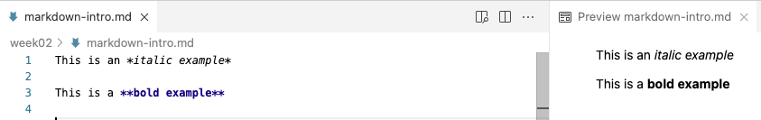

*A source Markdown file on the left, and a Preview of its rendered form on the right.*

### 2.2 An example document

Now, let’s learn some additional Markdown “syntax” (grammar/rules) by typing what is shown on the left, and seeing the effects in the live Preview in VS Code:

**Type:**

````
# The title is: Intro to Markdown

- One # makes a "level 1 header"
- Two ## makes a "level 2 header"
- **And so forth**

## Section 1: The basics

1. When you create a _numbered_ list,
1. numbers don't even need to increment.

----

## Section 2: Shell commands

Backticks as in `date` result in inline
code formatting.
But you may want whole "blocks" of code:

```bash
# Print the current date and time
date
```
````

**That should be rendered into the following preview:**

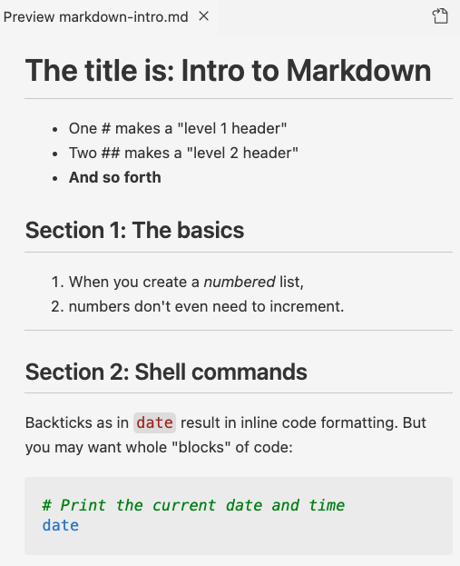

### 2.3 Most common Markdown syntax

Here is an overview of some of the syntax we used above:

| Syntax/source | Result/rendered output |
| --- | --- |
| *italic* | *italic* text (or use one underscore: _italic_) |
| **bold** | **bold** text (or use two underscores: __bold__) |
| # My Title | Header level 1 (largest: *use for the document’s title*) |
| ## My Section | Header level 2 (smaller – and so forth for additional header levels) |
| - List item | Unordered (bulleted) list |
| 1. List item | Ordered (numbered) list |
| --- | Horizontal rule (line) – use at least 3 dashes |

Code-formatting related options:

| Syntax/source | Result/rendered output |
| --- | --- |
| `inline code` | “Code-formatted” text for inline use: `inline code` |
| `` ```bash `` `code-block code` `` ``` `` | `bash`-language code block: This will apply language-specific code formatting. Other languages can be specified equivalently, e.g. `` ```r `` creates an `R`-language code block. |
| `` ``` `` `code-block code` `` ``` `` | Generic/language-agnostic code block |

And some other commonly used Markdown syntax:

| Syntax/source | Result/rendered output |
| --- | --- |
| [link text](website.com) | Clickable link with “hidden” URL: [link text](https://website.com) |
| <https://website.com> | Clickable link with visible URL: https://website.com |
| > Text | Blockquote (like quoted text in emails) |

#### Exercise: Markdown

Add text to your `markdown-intro.md` document that would result in the following preview:

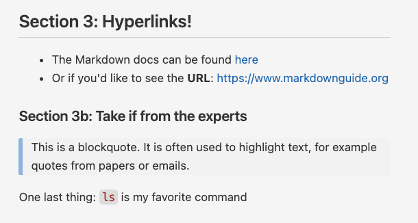

**Click for the solution**

```markdown
## Section 3: Hyperlinks!

- The Markdown docs can be found [here](https://www.markdownguide.org)
- Or if you'd like to see the **URL**: <https://www.markdownguide.org>

### Section 3b: Take if from the experts

> This is a blockquote. It is often used to highlight text, for example quotes from papers or emails.

One last thing: `ls` is my favorite command
```

### 2.4 Use whitespace around Markdown syntax elements

First, it’s highly recommended (and in some cases necessary for correct rendering) to leave a **blank line between different sections**, such as between lists, headers, and regular paragraphs:

```
## Chapter 2: List of ...

- Item 1
- Item 2

For example, ....
```

Second, leave a **space after** heading (`#`) and list (`-` or `1.`) characters or they won’t be interpreted correctly:

**This:**

```
##An important list

-x
-y
-z
```

**Will be rendered as:**

##An important list

-x -y -z

### 2.5 How whitespace renders in Markdown

You’ll have noticed Markdown doesn’t show always show whitespace (spaces, newlines, etc.) like you type it:

- A **single newline** is completely ignored!

**This:**

```
Line 1.
Line 2.
```

**Will be rendered as:**

Line 1. Line 2.

**This:**

```
Writing
one
word
per
line.
```

**Will be rendered as:**

Writing one word per line.

- But a **blank line** between regular text will start a new paragraph, with some whitespace between the two:

**This:**

```
Paragraph 1.

Paragraph 2.
```

**Will be rendered as:**

Paragraph 1.

Paragraph 2.

- Multiple consecutive spaces or blank lines will be **“collapsed”** into a single one:

**This:**

```
Empty             spaces
```

**Will be rendered as:**

Empty spaces

```
Many



blank lines
```

Many

blank lines

**TipHow to force additional whitespace *(Click to expand)**

- If you want **more vertical whitespace** than what is provided between paragraphs, you’ll have to resort to HTML (you can use any HTML markup in Markdown!) — each **`<br>`** item forces a visible linebreak:

**This:**

```
One <br> word <br> per line
and <br> <br> <br> <br> <br>
several blank lines.
```

**Will be rendered as:**

One  
word  
per line and  
several blank lines.

- A single **linebreak** (as opposed to a new paragraph) can be forced using *two or more spaces* (i.e., press the spacebar twice) or a backslash `\` after the last character on a line:

**This:**

```
My first sentence.\
My second sentence.
```

**Will be rendered as:**

My first sentence.  
My second sentence.

**NoteHow to create tables in Markdown *(Click to expand)**

Tables are a bit of a pain to make, but you can do so with vertical bars `|` and dashes/hyphens `-` as follows:

*This:*

```markdown
| city       | inhabitants |
|------------|-------------|
| Columbus   | 906 K       |
| Cleveland  | 368 K       |
| Cincinnati | 308 K       |
```

*Will be rendered as:*

| city | inhabitants |
| --- | --- |
| Columbus | 906 K |
| Cleveland | 368 K |
| Cincinnati | 308 K |

### 2.6 In closing

Markdown is useful for documentation because it is:

- *Easy to write* – you only need to know a dozen or so syntax constructs to be able to write Markdown.
- *Easy to read in source form* – and VS Code will apply some formatting even in source files!
- *A de facto standard* for documentation files in computational fields, such that e.g. GitHub, where you will learn to share your project files to in week 4, will render them for you.

Therefore, we recommend you use Markdown files (with a `.md` extension) instead of regular text (`.txt`) files to write the kind of documentation of your research projects we discussed in the previous session.

Producing a rendered output file like a HTML or PDF from Markdown yourself is rarely need for the abovementioned reasons. That said, if you do need to render a Markdown file to e.g. HTML or PDF, use [*Pandoc*](https://pandoc.org/installing.html).

#### Markdown for everything!?

Several **Markdown extensions** allow Markdown documents to *contain code that runs*, with that code’s output then included in rendered documents! For example, R Markdown (`.Rmd`) and the follow-up [Quarto](https://quarto.org/) — you will learn Quarto later in this course.

All in all, there are many possibilities with Markdown and its extensions! For instance, consider that:

- This entire website, including last week’s slides, is written using Quarto.
- Quarto also has support for citations and journal-specific formatting, so you can even write manuscripts with it.

Learn more about Markdown and its syntax on this excellent documentation site: https://www.markdownguide.org.

Back to top